# Predicting_Income_Project

## 1. Introduction to the Dataset

```python
import pandas as pd
```

```python
df = pd.read_csv('income.csv')
```

```python
for col in df.columns:
    counts = df[col].value_counts()
    print(f'dataframe[{col}]')
    print(counts)
    print('\n')
```

```
dataframe[age]
36    1348
35    1337
33    1335
23    1329
31    1325
      ...
88       6
85       5
87       3
89       2
86       1
Name: age, Length: 74, dtype: int64


dataframe[workclass]
Private             33906
Self-emp-not-inc     3862
Local-gov            3136
?                    2799
State-gov            1981
Self-emp-inc         1695
Federal-gov          1432
Without-pay            21
Never-worked           10
Name: workclass, dtype: int64


dataframe[fnlwgt]
203488    21
190290    19
120277    19
125892    18
126569    18
          ..
188488     1
285290     1
293579     1
114874     1
257302     1
```

[output cut: 178 more lines]

```
Trinadad&Tobago                  27
Laos                             23
Yugoslavia                       23
Outlying-US(Guam-USVI-etc)       23
Scotland                         21
Honduras                         20
Hungary                          19
Holand-Netherlands                1
Name: native-country, dtype: int64


dataframe[income]
<=50K    37155
>50K     11687
Name: income, dtype: int64
```

From the result above, we can summary the dataset description.

### Dataset description

The dataset contains the following features:

#### Dropping `fnlwgt` column

The `fnlwgt` column represents the estimated number of people for each row, and it is not directly related to the target variable `income`. Therefore, it is not useful for making predictions and can be dropped from the dataset to prevent any potential bias in the results.

```python
df = df.drop('fnlwgt', axis=1)
```

## 2. One-Hot Encoding

From the Dataset description we know that there are

#### Multi-class columns

- `education`: Bachelors, Some-college, 11th, HS-grad, Prof-school, Assoc-acdm, Assoc-voc, 9th, 7th-8th, 12th, Masters, 1st-4th, 10th, Doctorate, 5th-6th, Preschool.
- `marital-status`: Married-civ-spouse, Divorced, Never-married, Separated, Widowed, Married-spouse-absent, Married-AF-spouse.
- `occupation`: Tech-support, Craft-repair, Other-service, Sales, Exec-managerial, Prof-specialty, Handlers-cleaners, Machine-op-inspct, Adm-clerical, Farming-fishing, Transport-moving, Priv-house-serv, Protective-serv, Armed-Forces.
- `race`: White, Asian-Pac-Islander, Amer-Indian-Eskimo, Other, Black.
- `native-country`: United-States, Cambodia, England, Puerto-Rico, Canada, Germany, Outlying-US(Guam-USVI-etc), India, Japan, Greece, South, China, Cuba, Iran, Honduras, Philippines, Italy, Poland, Jamaica, Vietnam, Mexico, Portugal, Ireland, France, Dominican-Republic, Laos, Ecuador, Taiwan, Haiti, Columbia, Hungary, Guatemala, Nicaragua, Scotland, Thailand, Yugoslavia, El-Salvador, Trinadad&Tobago, Peru, Hong, Holand-Netherlands.

## One-Hot Encoding Multi-Class Columns

Encoding Multi-Class Columns

```python
df = pd.concat([df.drop('workclass', axis=1), pd.get_dummies(df['workclass']).add_prefix('workclass_')], axis=1)
df = pd.concat([df.drop('occupation', axis=1), pd.get_dummies(df['occupation']).add_prefix('occupation_')], axis=1)
df = df.drop('education', axis=1)
df = pd.concat([df.drop('marital-status', axis=1), pd.get_dummies(df['marital-status']).add_prefix('marital-status_')], axis=1)
df = pd.concat([df.drop('relationship', axis=1), pd.get_dummies(df['relationship']).add_prefix('relationship_')], axis=1)
df = pd.concat([df.drop('race', axis=1), pd.get_dummies(df['race']).add_prefix('race_')], axis=1)
df = pd.concat([df.drop('native-country', axis=1), pd.get_dummies(df['native-country']).add_prefix('native-country_')], axis=1)
```

## Encoding Binary-Class Columns

Encoding Binary-Class Columns

```python
df['gender'] = df['gender'].apply(lambda x: 1 if x == 'Male' else 0)
df['income'] = df['income'].apply(lambda x: 1 if x == '>50K' else 0)
```

## 3. Feature Selection, Most Correlated With Income

```python
df.shape
```

```
(48842, 91)
```

#### Filtering Top 20% Most Correlated Columns with the `Income` Column

Since we have a dataset with 91 columns, we want to identify the top 20% of columns that are most correlated with the `income` column. To achieve this, we can calculate the correlation between each column and the `income` column, and then select the columns with the highest correlation coefficients.

```python
income_corr = df.corr()['income'].abs()
sorted_income_corr = income_corr.sort_values()
num_cols_to_drop = int(0.8 * len(df.columns))
cols_to_keep = sorted_income_corr.iloc[num_cols_to_drop : ].index
df_most_corr = df[cols_to_keep]
```

#### Plotting The Correlation Heatmap

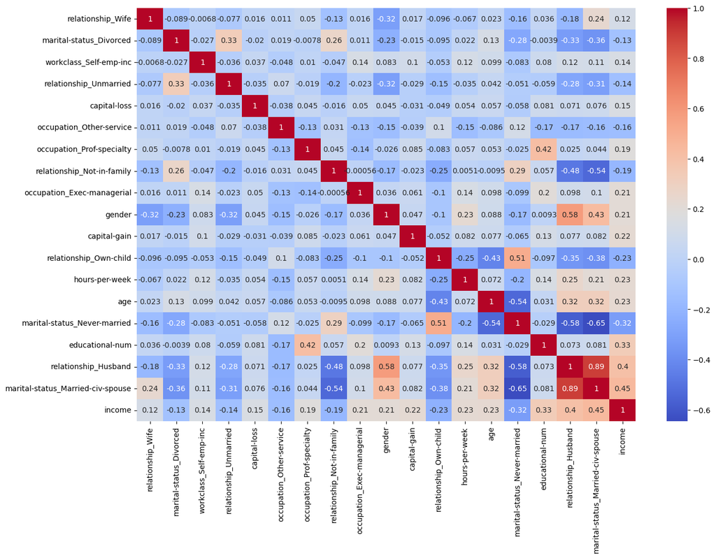

```python
import seaborn as sns
import matplotlib.pyplot as plt
plt.figure(figsize = (15, 10))
sns.heatmap(df_most_corr.corr(), annot=True, cmap='coolwarm');
```

Based on the heatmap analysis, the following features are found to be most correlated with the `income` column:

- Marital status
- Husband relationship
- Education level
- Age

This information can be useful for feature selection and building a predictive model for `income`.

## 4. Building Machine Learning Model

### Why Should be Random Forest Model?

Considering that we have already applied one-hot encoding for multi-class columns and binary encoding for binary-class columns, the decision tree emerges as a suitable model for predicting income. Nevertheless, it's important to note that decision trees can tend to overfit the training dataset. Therefore, utilizing **Random Forest**, an ensemble of decision trees, can help mitigate overfitting and lead to more robust predictions for income. Hence, the Random Forest model is likely to provide the best results when predicting `income`.

### Dividing the Dataset into the Training Data and the Testing Data

```python
from sklearn.model_selection import train_test_split

X = df.drop('income', axis=1)
y = df['income']
X_train, X_test, y_train, y_test = train_test_split(X, y, test_size=0.2)
```

#### Applying The Random Forest Classifier Model

```python
from sklearn.ensemble import RandomForestClassifier
clf = RandomForestClassifier().fit(X_train, y_train)
clf.score(X_test, y_test)
```

```
0.8496263691268298
```

#### Analyzing The Features Importance

```python
feature_imp = dict(zip(clf.feature_names_in_, clf.feature_importances_))
feature_imp = {k: v for k,v in sorted(feature_imp.items(), key = lambda x: x[1], reverse=True)}
feature_imp
```

```
{'age': 0.22322233494447943,
 'educational-num': 0.1311826117279202,
 'hours-per-week': 0.11350407412031566,
 'capital-gain': 0.10854257519814174,
 'marital-status_Married-civ-spouse': 0.07285802131856205,
 'relationship_Husband': 0.054071865666143,
 'capital-loss': 0.03623408938158132,
 'marital-status_Never-married': 0.02570174793814733,
 'occupation_Exec-managerial': 0.021618843393805664,
 'occupation_Prof-specialty': 0.017875105317731954,
 'gender': 0.013889273602117912,
 'relationship_Not-in-family': 0.010563681520294483,
 'workclass_Private': 0.009653923427601437,
 'relationship_Own-child': 0.008426776216139093,
 'workclass_Self-emp-not-inc': 0.008300231271496155,
 'relationship_Wife': 0.00795649380744919,
 'occupation_Other-service': 0.007734290828360036,
 'native-country_United-States': 0.0064937340627310445,
 'marital-status_Divorced': 0.0063637295755381166,
 'race_White': 0.006223073287283066,
 'occupation_Sales': 0.006051784217098677,
 'workclass_Self-emp-inc': 0.00601461315741399,
 'occupation_Craft-repair': 0.005939820440652321,
 'relationship_Unmarried': 0.005749606215869169,
 'workclass_Local-gov': 0.005398525105848354,
 'occupation_Adm-clerical': 0.005145963881619278,
 'workclass_Federal-gov': 0.005086183145137154,
 'race_Black': 0.004796416481660459,
 'occupation_Farming-fishing': 0.0047604968012297825,
 'workclass_State-gov': 0.004412370339855017,
 'occupation_Tech-support': 0.0040771021673870105,
 'occupation_Machine-op-inspct': 0.004061759162365423,
 'occupation_Transport-moving': 0.003942784452512743,
 'occupation_Handlers-cleaners': 0.0033955311356353925,
 'race_Asian-Pac-Islander': 0.00293520185458387,
 'native-country_?': 0.0028921094649814356,
 'occupation_Protective-serv': 0.0026519234782636236,
 'native-country_Mexico': 0.0026285800906803384,
 'marital-status_Separated': 0.0020013038539824536,
 'relationship_Other-relative': 0.0019994140634655012,
```

[output cut: 35 more lines]

```
 'native-country_Haiti': 0.00019330228615587253,
 'occupation_Priv-house-serv': 0.00018751479833655982,
 'native-country_Hong': 0.00013972805660000248,
 'native-country_Nicaragua': 0.000136058734038263,
 'native-country_Guatemala': 0.00013347680168018442,
 'native-country_Scotland': 0.00012227616818582268,
 'native-country_Trinadad&Tobago': 0.00011930826974066256,
 'workclass_Without-pay': 0.00011617143550319518,
 'native-country_Laos': 9.009014864171938e-05,
 'native-country_Thailand': 8.255386512834968e-05,
 'occupation_Armed-Forces': 7.978436171451954e-05,
 'native-country_Outlying-US(Guam-USVI-etc)': 5.077876426342873e-05,
 'native-country_Honduras': 3.551547200466243e-05,
 'workclass_Never-worked': 5.655835812791772e-06,
 'native-country_Holand-Netherlands': 0.0}
```

#### Feature Importance in Machine Learning Model

The code provided calculates and displays the importance of different features in a machine learning model. In simpler terms, it tells us which aspects or characteristics of the data are most important for making predictions with the model.

The importance percentages next to each feature indicate how much each feature contributes to the model's ability to predict income. Features with higher importance percentages are more influential in making accurate predictions.

In summary, this information helps us understand which aspects of the data are crucial for the model's predictions. It can be valuable for decision-makers and data analysts to focus on these top features when trying to explain or improve the model's performance.

# 5. Hyperparameter Tuning

Utilizing **GridSearchCV** from sklearn.model_selection, we aim to determine the optimal parameter values for the Random Forest Classification model. Specifically, we are seeking the best values for the following parameters within the `RandomForestClassifier`: `n_estimators`, `max_depth`, `min_samples_split`, and `max_features`.

```python
from sklearn.model_selection import GridSearchCV
from sklearn.ensemble import RandomForestClassifier

# Define the parameter grid for hyperparameter tuning
param_grid = {
    'n_estimators': [200, 300, 400],           # List of different values for n_estimators
    'max_depth': [None, 20, 30, 40],          # List of different values for max_depth
    'min_samples_split': [5, 8, 11],         # List of different values for min_samples_split
    'max_features': ['auto', 'sqrt', 'log2']  # List of different values for max_features
}

# Create the RandomForestClassifier
rf_classifier = RandomForestClassifier()

# Create the GridSearchCV object
grid_search = GridSearchCV(rf_classifier, param_grid=param_grid, verbose=10, n_jobs=-1)

# Fit the grid search to the training data
grid_search.fit(X_train, y_train)
```

```
Fitting 5 folds for each of 108 candidates, totalling 540 fits
```

#### Get The Best Parameters

```python
grid_search.best_params_
```

[output not shown]

#### Get The Best Score

```python
best_estimator = grid_search.best_estimator_
best_estimator.score(X_test, y_test)
```

[output not shown]